# This notebook is designed to try and use the `multi_molecule` and `multi_reaction` classes to perform conformer analysis

```python
import os
import sys
import logging
FORMAT = "%(filename)s:%(lineno)d %(funcName)s %(levelname)s %(message)s"
logging.basicConfig(format=FORMAT, level=logging.INFO)

import re
import imp
import itertools
import random
import numpy as np
from numpy import array
import pandas as pd
import matplotlib
matplotlib.use('Agg')
%matplotlib inline
from matplotlib import pyplot as plt
import seaborn as sns


# do this before we have a chance to import openbabel!
import rdkit, rdkit.Chem.rdDistGeom, rdkit.DistanceGeometry

from rdkit import Chem
from rdkit.Chem import AllChem
from rdkit import rdBase

import py3Dmol

from rmgpy.molecule import Molecule
from rmgpy.species import Species
from rmgpy.reaction import Reaction


from multi_molecule import *
from multi_reaction import *

from ase.calculators.morse import * #chosing this calculator for now because it's fast
from ase.calculators.dftb import *
from ase.calculators.lj import *
from ase.calculators.emt import *
```

```python
mol = Multi_Molecule("COCCC")
mol.view_mol()
```

```python
mol.torsions
```

```
[<multi_molecule.Torsion instance at 0x112cef0e0>,
 <multi_molecule.Torsion instance at 0x112cef2d8>]
```

```python
calc = EMT()
mol.ase_molecule.set_calculator(calc)
```

### Okay, not we have a molecule that we're working with. It has two torsions and a calculators attached. We're using a cheap calculator at the moment because it's fast

```python
mol.ase_molecule.get_potential_energy()
```

```
4.944702033490999
```

#### The following methodology is pretty consistent with what we've used in previous notebooks

```python
torsion_list = mol.torsions
torsion_angles = np.arange(0, 360+10,10)
torsion_combos = list( itertools.combinations_with_replacement( torsion_angles, len(torsion_list)) )
if len(torsion_list) != 1:
    torsion_combos = list(
        set(
            torsion_combos +
            list(itertools.combinations_with_replacement(
                torsion_angles[::-1], len(torsion_list)
            ))))
torsion_combos
```

```
[(110, 190),
 (330, 240),
 (170, 130),
 (210, 310),
 (130, 170),
 (170, 70),
 (30, 100),
 (120, 180),
 (150, 280),
 (90, 130),
 (290, 320),
 (240, 160),
 (140, 100),
 (170, 250),
 (10, 310),
 (20, 280),
 (170, 220),
 (30, 220),
 (270, 160),
 (40, 230),
 (150, 160),
 (220, 60),
 (120, 120),
 (250, 330),
 (30, 180),
 (90, 60),
 (80, 250),
 (40, 290),
 (60, 240),
 (210, 110),
 (90, 350),
 (20, 200),
 (80, 280),
 (190, 280),
 (0, 180),
 (150, 80),
 (140, 30),
 (50, 10),
 (60, 280),
 (280, 30),
```

[output cut: 946 more lines]

```
 (360, 130),
 (250, 40),
 (200, 150),
 (110, 50),
 (270, 40),
 (160, 350),
 (110, 360),
 (20, 80),
 (170, 30),
 (320, 20),
 (90, 220),
 (60, 110),
 (280, 300),
 (50, 20),
 ...]
```

```python
results = []
for combo in torsion_combos:
    geo = zip(torsion_list, combo)
    #print geo
    for torsion in geo:
        tor = torsion[0]
        #print tor
        angle = torsion[1]

        i,j,k,l = tor.indices
        RHS =  tor.RHS
        mol.ase_molecule.set_dihedral(a1 = i,
                                a2 = j,
                                a3 = k,
                                a4 = l,
                                angle= float(angle),
                                indices=RHS)
    mol.update_geometry_from_ase_mol()
    results.append(list(combo) + [mol.ase_molecule.get_potential_energy()])
results
```

```
[[110, 190, 4.945561543622329],
 [330, 240, 4.923926819413028],
 [170, 130, 4.944873301397132],
 [210, 310, 4.932725160829996],
 [130, 170, 4.946281192401006],
 [170, 70, 4.93424451318494],
 [30, 100, 4.928632615038563],
 [120, 180, 4.946245162390607],
 [150, 280, 4.938929064651969],
 [90, 130, 4.942037309103305],
 [290, 320, 4.959998839882726],
 [240, 160, 4.947601697050648],
 [140, 100, 4.942993799312922],
 [170, 250, 4.943695598211369],
 [10, 310, 5.2446639084201845],
```

[output cut: 986 more lines]

```python
df = pd.DataFrame(results)
columns = ["Energy"]
for i in range(len(torsion_list)):
    columns = ["Torsion " + str(i)] + columns

df.columns = columns

df.sort("Energy")
```

|  | Torsion 1 | Torsion 0 | Energy |
| --- | --- | --- | --- |
| 93 | 0 | 290 | 4.897462 |
| 702 | 360 | 290 | 4.897462 |
| 1220 | 10 | 290 | 4.898671 |
| 390 | 340 | 300 | 4.899323 |
| 510 | 350 | 290 | 4.899338 |
| 532 | 350 | 300 | 4.899835 |
| 157 | 330 | 300 | 4.900793 |
| 692 | 320 | 310 | 4.901950 |
| 1361 | 340 | 290 | 4.901989 |
| 512 | 330 | 310 | 4.902187 |
| 1269 | 360 | 280 | 4.903822 |
| 767 | 0 | 280 | 4.903822 |
| 582 | 10 | 280 | 4.903865 |
| 153 | 350 | 280 | 4.904981 |
| 1027 | 320 | 300 | 4.905338 |
| 283 | 360 | 300 | 4.905919 |
| 304 | 0 | 300 | 4.905919 |
| 351 | 330 | 290 | 4.906150 |
| 15 | 20 | 280 | 4.906543 |
| 94 | 320 | 90 | 4.906599 |
| 1103 | 330 | 90 | 4.907125 |
| 766 | 340 | 280 | 4.907739 |
| 410 | 310 | 310 | 4.908782 |
| 1174 | 310 | 90 | 4.908882 |
| 419 | 310 | 80 | 4.908909 |
| 318 | 320 | 320 | 4.909753 |
| 118 | 300 | 80 | 4.910376 |
| 227 | 340 | 90 | 4.910518 |
| 131 | 360 | 270 | 4.910553 |
| 155 | 0 | 270 | 4.910553 |
| ... | ... | ... | ... |
| 809 | 10 | 20 | 24.842848 |
| 683 | 340 | 350 | 25.055059 |
| 1288 | 30 | 360 | 26.379122 |
| 1121 | 30 | 0 | 26.379122 |
| 1195 | 320 | 10 | 26.568368 |
| 1253 | 330 | 360 | 27.827301 |
| 447 | 330 | 0 | 27.827303 |
| 1087 | 60 | 330 | 29.276921 |
| 781 | 40 | 330 | 29.616948 |
| 890 | 60 | 320 | 30.877973 |
| 1141 | 40 | 350 | 31.055838 |
| 317 | 30 | 340 | 32.792097 |
| 478 | 340 | 40 | 33.902269 |
| 695 | 20 | 350 | 35.054838 |
| 201 | 340 | 30 | 35.913209 |
| 815 | 50 | 340 | 36.621386 |
| 664 | 10 | 0 | 37.257089 |
| 154 | 10 | 360 | 37.257089 |
| 614 | 0 | 10 | 40.296671 |
| 592 | 360 | 10 | 40.296671 |
| 853 | 350 | 20 | 44.499008 |
| 1199 | 20 | 0 | 56.137541 |
| 129 | 20 | 360 | 56.137542 |
| 477 | 10 | 10 | 60.082251 |
| 708 | 30 | 350 | 62.712457 |
| 711 | 360 | 20 | 75.343382 |
| 273 | 0 | 20 | 75.343382 |
| 50 | 50 | 330 | 75.579316 |
| 685 | 350 | 30 | 76.025429 |
| 553 | 40 | 340 | 79.538784 |

1369 rows × 3 columns

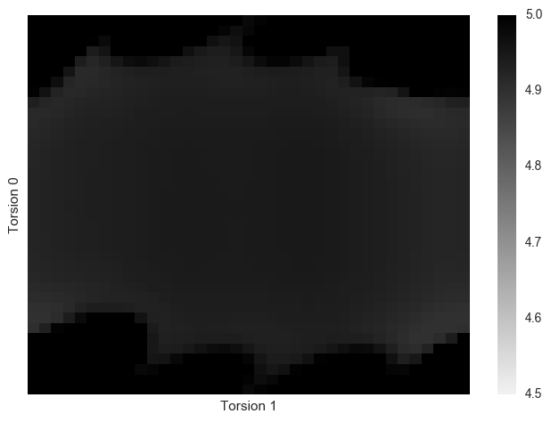

```python
dff = df.pivot(index="Torsion 0", columns="Torsion 1", values="Energy")
sns.set()
sns.heatmap(dff,
            cmap = sns.light_palette("black", as_cmap=True),
            vmin =4.5, vmax=5,
            xticklabels=[], yticklabels=[])
```

#### Now the above is showing us that we have some minima, but it's pretty hazy. This is probably attributed to the calculator that we are using. Moving forward we want to use `dftb` or `hotbit`. These are faster than traditional DFT calcs, but more accurate than force field calcs

## Now, putting this all thogether into one cell (mainly for scripting purposes)

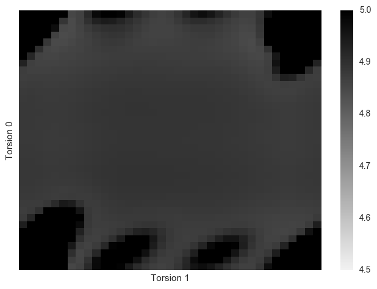

```python
mol = Multi_Molecule("COCCC") ### You can change the molecule of interest
calc = EMT() ### You can change the calculator
mol.ase_molecule.set_calculator(calc)

# Getting the torsion combos
torsion_list = mol.torsions
torsion_angles = np.arange(0, 360+10,10) ### You can change the degree step size
torsion_combos = list( itertools.combinations_with_replacement( torsion_angles, len(torsion_list)) )
if len(torsion_list) != 1:
    torsion_combos = list(
        set(
            torsion_combos +
            list(itertools.combinations_with_replacement(
                torsion_angles[::-1], len(torsion_list)
            ))))

    results = []

# Calculating the potential energy for each conformation
for combo in torsion_combos:
    geo = zip(torsion_list, combo)
    #print geo
    for torsion in geo:
        tor = torsion[0]
        #print tor
        angle = torsion[1]

        i,j,k,l = tor.indices
        RHS =  tor.RHS
        mol.ase_molecule.set_dihedral(a1 = i,
                                a2 = j,
                                a3 = k,
                                a4 = l,
                                angle= float(angle),
                                indices=RHS)
    mol.update_geometry_from_ase_mol()
    results.append(list(combo) + [mol.ase_molecule.get_potential_energy()])

# Creating a dataframe of the results
df = pd.DataFrame(results)
columns = ["Energy"]
for i in range(len(torsion_list)):
    columns = ["Torsion " + str(i)] + columns

df.columns = columns

# Visualizing the results (may not be necessary for scripting)
dff = df.pivot(index="Torsion 0", columns="Torsion 1", values="Energy")
sns.set()
sns.heatmap(dff,
            cmap = sns.light_palette("black", as_cmap=True),
            vmin =4.5, vmax=5,
            xticklabels=[], yticklabels=[])
```

#### And we get pretty similar results to the above trial.

# Now to try this for transition states

```python
rxn = Multi_Reaction("CCCCCC+[O]O_[CH2]CCCCC+OO", "H_Abstraction")
rxn
```

```
reaction.py:300 generateBoundsMatrix INFO Generating bounds matrix for CCCCCC.[O]O
reaction.py:338 bmPreEdit INFO Changing lower limit 2.9 to 2.393074
reaction.py:338 bmPreEdit INFO Changing lower limit 3.65 to 3.26214059416
reaction.py:338 bmPreEdit INFO Changing lower limit 2.520343 to 2.457475
```

```
<multi_reaction.Multi_Reaction instance at 0x115318368>
```

```python
print len(rxn.multi_ts.torsions)
rxn.multi_ts.view_ts()
```

```
6
```

### So, we've set up the reaction and gotten a guess for the TS. Also, we correctly identified the torsions... I think

```python
print AllChem.MolToMolBlock(rxn.multi_ts.rdkit_ts)
print rxn.multi_ts.rmg_ts.atoms[14]
print rxn.multi_ts.rmg_ts.atoms[20]
print rxn.multi_ts.rmg_ts.atoms[19]
```

```
     RDKit          3D

 23 21  0  0  0  0  0  0  0  0999 V2000
   -0.8505   -0.0564    0.8993 C   0  0  0  0  0  0  0  0  0  0  0  0
   -1.0267   -1.4677    0.3071 C   0  0  0  0  0  0  0  0  0  0  0  0
   -0.8805    1.0730   -0.1487 C   0  0  0  0  0  0  0  0  0  0  0  0
    0.2123   -1.9932   -0.4449 C   0  0  0  0  0  0  0  0  0  0  0  0
    0.5175    1.5744   -0.5045 C   0  0  0  0  0  0  0  0  0  0  0  0
    0.0771   -1.8617   -1.9619 C   0  0  0  0  0  0  0  0  0  0  0  0
   -1.4171    0.7561   -1.0683 H   0  0  0  0  0  0  0  0  0  0  0  0
   -1.4435    1.9344    0.2718 H   0  0  0  0  0  0  0  0  0  0  0  0
    0.0731   -0.0114    1.5177 H   0  0  0  0  0  0  0  0  0  0  0  0
   -1.6986    0.1105    1.5995 H   0  0  0  0  0  0  0  0  0  0  0  0
   -1.2210   -2.1558    1.1592 H   0  0  0  0  0  0  0  0  0  0  0  0
   -1.9357   -1.5055   -0.3330 H   0  0  0  0  0  0  0  0  0  0  0  0
    1.1373   -1.4832   -0.1010 H   0  0  0  0  0  0  0  0  0  0  0  0
    0.3380   -3.0736   -0.2135 H   0  0  0  0  0  0  0  0  0  0  0  0
    1.1302    2.0735    0.6130 H   0  0  0  0  0  0  0  0  0  0  0  0
    0.4397    2.3866   -1.2575 H   0  0  0  0  0  0  0  0  0  0  0  0
    1.1412    0.7622   -0.9269 H   0  0  0  0  0  0  0  0  0  0  0  0
    0.9951   -2.2514   -2.4500 H   0  0  0  0  0  0  0  0  0  0  0  0
   -0.0576   -0.8043   -2.2632 H   0  0  0  0  0  0  0  0  0  0  0  0
   -0.7911   -2.4536   -2.3220 H   0  0  0  0  0  0  0  0  0  0  0  0
    1.8950    3.2716    2.5740 O   0  0  0  0  0  0  0  0  0  0  0  0
    1.5899    2.4036    1.6330 O   0  0  0  0  0  1  0  0  0  0  0  0
    1.7758    2.7718    3.4206 H   0  0  0  0  0  0  0  0  0  0  0  0
  1  9  1  0
  1 10  1  0
  1  3  1  0
  1  2  1  0
  2 12  1  0
  2 11  1  0
  2  4  1  0
  3  5  1  0
  3  7  1  0
  3  8  1  0
  4 13  1  0
  4 14  1  0
  4  6  1  0
  5 16  1  0
  5 17  1  0
  5 15  1  0
  6 20  1  0
  6 18  1  0
  6 19  1  0
 21 23  1  0
 21 22  1  0
M  RAD  1  22   2
M  END

H
O
H
```

```python
from copy import deepcopy
TS = deepcopy(rxn.multi_ts)
```

### Okay, I don't think we've correctly identified the torsions in this TS.... this will be something to look at in a lil bit

```python
TS.view_ts()
```

```python
tor = TS.torsions[5]
```

```python
i,j,k,l = tor.indices
RHS = tor.RHS
LHS= tor.LHS
```

```python
TS.ase_ts.get_dihedral(i,j,k,l)
```

```
230.91900609499339
```

```python
TS.ase_ts.set_dihedral(i,j,k,l, indices=RHS, angle=float(180))
TS.update_ts_from_ase_ts()
TS.view_ts()
```

```python
TS.torsion_list
```

```
[(1, 0, 2, 4),
 (2, 0, 1, 3),
 (0, 1, 3, 5),
 (0, 2, 4, 14),
 (2, 4, 14, 21),
 (4, 14, 21, 20)]
```

### okay... idk what happened, but this is working right now

### Now let's recopy the TS

```python
TS = deepcopy(rxn.multi_ts)
```

```python
TS.ase_ts.set_calculator(calc)
```

```python
# Getting the torsion combos
torsion_list = TS.torsions
torsion_angles = np.arange(0, 360+30,30) ### You can change the degree step size
torsion_combos = list( itertools.combinations_with_replacement( torsion_angles, len(torsion_list)) )
if len(torsion_list) != 1:
    torsion_combos = list(
        set(
            torsion_combos +
            list(itertools.combinations_with_replacement(
                torsion_angles[::-1], len(torsion_list)
            ))))

    results = []

# Calculating the potential energy for each conformation
for combo in torsion_combos:

    geo = zip(torsion_list, combo)
    #print geo
    for torsion in geo:
        tor = torsion[0]
        #print tor
        angle = torsion[1]

        i,j,k,l = tor.indices
        RHS =  tor.RHS
        TS.ase_ts.set_dihedral(a1 = i,
                                a2 = j,
                                a3 = k,
                                a4 = l,
                                angle= float(angle),
                                indices=RHS)
    TS.update_ts_from_ase_ts()
    results.append(list(combo) + [TS.ase_ts.get_potential_energy()])

# Creating a dataframe of the results
df = pd.DataFrame(results)
columns = ["Energy"]
for i in range(len(torsion_list)):
    columns = ["Torsion " + str(i)] + columns

df.columns = columns

# Visualizing the results (may not be necessary for scripting)
"""dff = df.pivot(index="Torsion 0", columns="Torsion 1", values="Energy")
sns.set()
sns.heatmap(dff,
            cmap = sns.light_palette("black", as_cmap=True),
            vmin =4.5, vmax=5,
            xticklabels=[], yticklabels=[])"""

df
```

|  | Torsion 5 | Torsion 4 | Torsion 3 | Torsion 2 | Torsion 1 | Torsion 0 | Energy |
| --- | --- | --- | --- | --- | --- | --- | --- |
| 0 | 30 | 30 | 60 | 270 | 360 | 360 | 9.989095 |
| 1 | 210 | 210 | 240 | 270 | 330 | 360 | 9.043579 |
| 2 | 360 | 330 | 180 | 150 | 150 | 60 | 16.679694 |
| 3 | 60 | 90 | 120 | 120 | 240 | 300 | 9.035586 |
| 4 | 60 | 60 | 60 | 90 | 180 | 270 | 9.017654 |
| 5 | 330 | 270 | 270 | 180 | 150 | 0 | 9.030799 |
| 6 | 360 | 300 | 240 | 150 | 120 | 0 | 9.071762 |
| 7 | 360 | 300 | 270 | 210 | 210 | 90 | 9.022393 |
| 8 | 300 | 240 | 240 | 210 | 120 | 60 | 9.037059 |
| 9 | 0 | 120 | 210 | 210 | 240 | 360 | 9.068284 |
| 10 | 60 | 120 | 210 | 300 | 360 | 360 | 9.122395 |
| 11 | 300 | 270 | 240 | 120 | 120 | 60 | 9.035665 |
| 12 | 60 | 60 | 90 | 120 | 210 | 300 | 9.024567 |
| 13 | 360 | 270 | 270 | 240 | 240 | 150 | 9.092661 |
| 14 | 0 | 120 | 120 | 180 | 300 | 360 | 9.030871 |
| 15 | 300 | 270 | 180 | 120 | 120 | 120 | 9.037169 |
| 16 | 300 | 180 | 150 | 30 | 30 | 0 | 9.663413 |
| 17 | 270 | 270 | 210 | 210 | 30 | 0 | 9.039014 |
| 18 | 90 | 90 | 90 | 90 | 330 | 360 | 9.038852 |
| 19 | 270 | 240 | 150 | 150 | 150 | 30 | 9.044458 |
| 20 | 240 | 90 | 90 | 90 | 90 | 0 | 9.037468 |
| 21 | 360 | 300 | 180 | 120 | 0 | 0 | 9.150786 |
| 22 | 210 | 210 | 210 | 210 | 90 | 30 | 9.047409 |
| 23 | 360 | 270 | 210 | 180 | 180 | 0 | 9.022949 |
| 24 | 150 | 150 | 240 | 300 | 360 | 360 | 9.044956 |
| 25 | 60 | 120 | 120 | 330 | 330 | 330 | 9.081408 |
| 26 | 30 | 90 | 120 | 120 | 240 | 330 | 9.062321 |
| 27 | 330 | 330 | 240 | 120 | 90 | 60 | 9.029782 |
| 28 | 60 | 60 | 60 | 150 | 150 | 210 | 9.018328 |
| 29 | 360 | 360 | 360 | 240 | 30 | 30 | 51.303642 |
| ... | ... | ... | ... | ... | ... | ... | ... |
| 37085 | 360 | 270 | 90 | 90 | 30 | 30 | 9.607422 |
| 37086 | 360 | 360 | 300 | 300 | 60 | 60 | 32.313853 |
| 37087 | 360 | 270 | 240 | 240 | 150 | 150 | 9.093596 |
| 37088 | 0 | 30 | 120 | 240 | 270 | 300 | 10.045872 |
| 37089 | 30 | 30 | 120 | 120 | 210 | 240 | 9.023372 |
| 37090 | 120 | 150 | 150 | 180 | 300 | 360 | 9.046739 |
| 37091 | 30 | 60 | 150 | 330 | 330 | 360 | 10.170764 |
| 37092 | 0 | 60 | 60 | 150 | 210 | 270 | 9.027510 |
| 37093 | 0 | 0 | 30 | 60 | 300 | 300 | 142.122061 |
| 37094 | 300 | 270 | 210 | 150 | 150 | 90 | 9.034815 |
| 37095 | 30 | 210 | 270 | 270 | 270 | 330 | 9.033319 |
| 37096 | 30 | 240 | 240 | 240 | 300 | 360 | 9.046683 |
| 37097 | 90 | 120 | 210 | 240 | 330 | 330 | 9.040126 |
| 37098 | 60 | 60 | 150 | 180 | 360 | 360 | 9.029194 |
| 37099 | 240 | 210 | 150 | 90 | 30 | 30 | 9.043127 |
| 37100 | 300 | 270 | 180 | 180 | 90 | 30 | 9.034495 |
| 37101 | 0 | 90 | 90 | 150 | 270 | 360 | 9.045302 |
| 37102 | 30 | 120 | 150 | 210 | 360 | 360 | 9.074126 |
| 37103 | 0 | 0 | 90 | 120 | 150 | 240 | 30.078001 |
| 37104 | 120 | 180 | 180 | 180 | 270 | 360 | 9.048310 |
| 37105 | 30 | 120 | 120 | 210 | 240 | 240 | 9.074092 |
| 37106 | 360 | 240 | 240 | 120 | 120 | 90 | 9.365284 |
| 37107 | 360 | 330 | 240 | 150 | 30 | 0 | 21.031429 |
| 37108 | 0 | 60 | 120 | 120 | 330 | 360 | 9.050432 |
| 37109 | 60 | 60 | 60 | 180 | 210 | 270 | 9.018273 |
| 37110 | 330 | 180 | 30 | 30 | 30 | 0 | 9.345350 |
| 37111 | 360 | 270 | 210 | 150 | 90 | 90 | 9.031545 |
| 37112 | 0 | 0 | 30 | 240 | 300 | 330 | 94.015379 |
| 37113 | 330 | 270 | 210 | 210 | 120 | 90 | 9.032386 |
| 37114 | 0 | 240 | 300 | 300 | 300 | 360 | 9.034995 |

37115 rows × 7 columns

```python
df.sort("Energy")
```

|  | Torsion 5 | Torsion 4 | Torsion 3 | Torsion 2 | Torsion 1 | Torsion 0 | Energy |
| --- | --- | --- | --- | --- | --- | --- | --- |
| 32783 | 330 | 300 | 300 | 210 | 0 | 0 | 9.002446 |
| 16027 | 330 | 300 | 300 | 210 | 30 | 0 | 9.002554 |
| 3972 | 330 | 300 | 300 | 210 | 30 | 30 | 9.002601 |
| 29150 | 30 | 60 | 60 | 150 | 360 | 360 | 9.002643 |
| 32901 | 30 | 60 | 60 | 150 | 330 | 360 | 9.002740 |
| 25426 | 330 | 300 | 300 | 210 | 60 | 0 | 9.002782 |
| 7879 | 30 | 60 | 60 | 150 | 330 | 330 | 9.002783 |
| 18257 | 330 | 300 | 300 | 210 | 60 | 30 | 9.002828 |
| 9806 | 330 | 300 | 300 | 210 | 60 | 60 | 9.002884 |
| 5844 | 30 | 60 | 60 | 150 | 300 | 360 | 9.002966 |
| 30837 | 30 | 60 | 60 | 150 | 300 | 330 | 9.003011 |
| 5965 | 330 | 300 | 300 | 210 | 90 | 0 | 9.003050 |
| 1149 | 30 | 60 | 60 | 150 | 300 | 300 | 9.003068 |
| 2087 | 330 | 300 | 300 | 210 | 90 | 30 | 9.003086 |
| 18188 | 330 | 300 | 300 | 210 | 90 | 60 | 9.003127 |
| 4101 | 330 | 300 | 300 | 210 | 90 | 90 | 9.003165 |
| 30367 | 30 | 60 | 60 | 150 | 270 | 360 | 9.003240 |
| 5388 | 30 | 60 | 60 | 150 | 270 | 330 | 9.003276 |
| 12611 | 330 | 300 | 300 | 210 | 120 | 0 | 9.003284 |
| 4607 | 330 | 300 | 300 | 210 | 120 | 30 | 9.003307 |
| 17430 | 30 | 60 | 60 | 150 | 270 | 300 | 9.003321 |
| 25537 | 330 | 300 | 300 | 210 | 120 | 60 | 9.003336 |
| 29574 | 30 | 60 | 60 | 150 | 270 | 270 | 9.003363 |
| 17481 | 330 | 300 | 300 | 210 | 120 | 90 | 9.003365 |
| 1386 | 330 | 300 | 300 | 210 | 120 | 120 | 9.003384 |
| 28909 | 330 | 300 | 300 | 210 | 210 | 30 | 9.003409 |
| 629 | 330 | 300 | 300 | 210 | 210 | 0 | 9.003413 |
| 7948 | 330 | 300 | 300 | 210 | 210 | 60 | 9.003415 |
| 33634 | 330 | 300 | 300 | 210 | 210 | 90 | 9.003425 |
| 18442 | 330 | 300 | 300 | 210 | 150 | 0 | 9.003434 |
| ... | ... | ... | ... | ... | ... | ... | ... |
| 5237 | 360 | 360 | 330 | 330 | 60 | 60 | 186.478566 |
| 36103 | 360 | 360 | 330 | 330 | 120 | 60 | 187.216061 |
| 29490 | 360 | 360 | 330 | 330 | 120 | 90 | 187.231116 |
| 24715 | 360 | 360 | 330 | 330 | 120 | 30 | 187.237161 |
| 4478 | 360 | 360 | 330 | 330 | 120 | 120 | 187.267144 |
| 36782 | 360 | 360 | 330 | 330 | 120 | 0 | 187.298009 |
| 8312 | 0 | 0 | 150 | 330 | 330 | 360 | 189.366136 |
| 8092 | 360 | 360 | 330 | 330 | 90 | 90 | 190.463442 |
| 11705 | 360 | 360 | 330 | 330 | 90 | 60 | 190.464702 |
| 19516 | 360 | 360 | 330 | 330 | 90 | 0 | 190.487327 |
| 23729 | 360 | 360 | 330 | 330 | 90 | 30 | 190.490373 |
| 7334 | 0 | 0 | 150 | 330 | 360 | 360 | 192.005159 |
| 9099 | 30 | 30 | 180 | 300 | 360 | 360 | 203.375352 |
| 16031 | 0 | 0 | 270 | 330 | 330 | 330 | 211.410152 |
| 32222 | 0 | 0 | 270 | 330 | 330 | 360 | 211.482326 |
| 27092 | 0 | 0 | 270 | 330 | 360 | 360 | 212.413847 |
| 14720 | 360 | 300 | 150 | 0 | 0 | 0 | 214.097030 |
| 25861 | 360 | 330 | 150 | 30 | 30 | 30 | 215.167923 |
| 33779 | 360 | 330 | 150 | 30 | 0 | 0 | 216.265573 |
| 8332 | 360 | 330 | 270 | 30 | 30 | 30 | 217.003412 |
| 9337 | 360 | 330 | 150 | 30 | 30 | 0 | 217.388915 |
| 9578 | 360 | 330 | 270 | 30 | 0 | 0 | 217.401991 |
| 12573 | 360 | 330 | 270 | 30 | 30 | 0 | 220.432508 |
| 13997 | 0 | 30 | 90 | 330 | 360 | 360 | 224.107358 |
| 26992 | 0 | 30 | 210 | 330 | 330 | 330 | 226.035490 |
| 11690 | 0 | 30 | 210 | 330 | 360 | 360 | 229.172867 |
| 10837 | 0 | 30 | 210 | 330 | 330 | 360 | 229.500953 |
| 24321 | 0 | 30 | 90 | 330 | 330 | 360 | 229.510691 |
| 12253 | 0 | 30 | 90 | 330 | 330 | 330 | 231.761524 |
| 9586 | 360 | 330 | 210 | 0 | 0 | 0 | 233.090738 |

37115 rows × 7 columns

```python
TS.view_ts()
```